# MECH481A6: Engineering Data Analysis in R

Chapter 9 Homework: Transformations

Tyson Williams

10 November, 2025

# Chapter 9 Homework

This homework will give you practice at transforming and visualizing data and fitting a distribution to a set of data. Note that much of the code needed to complete this homework can be adapted from the [Coursebook Exercises](https://smogdr.github.io/edar_coursebook/transform.html#ch-9-exercises) in Chapter 9.

When a question asks you to make a plot, remember to set a theme, title, subtitle, labels, colors, etc. It is up to you how to personalize your plots, but put in some effort and make the plotting approach consistent throughout the document. For example, you could use the same theme for all plots.

## Question 1

Recreate Figure 9.8 (the three EDA plots based on `salary_ps2$salary`), but show the plots on a log-scale x-axis. Plot the histogram with 30 bins and move the legends so that they don’t block the data. Does the data in these plots appear more symmetric about the median? Why or why not?

Answer: I does appear more symetric and normal because the histogram pulls in the outliers.

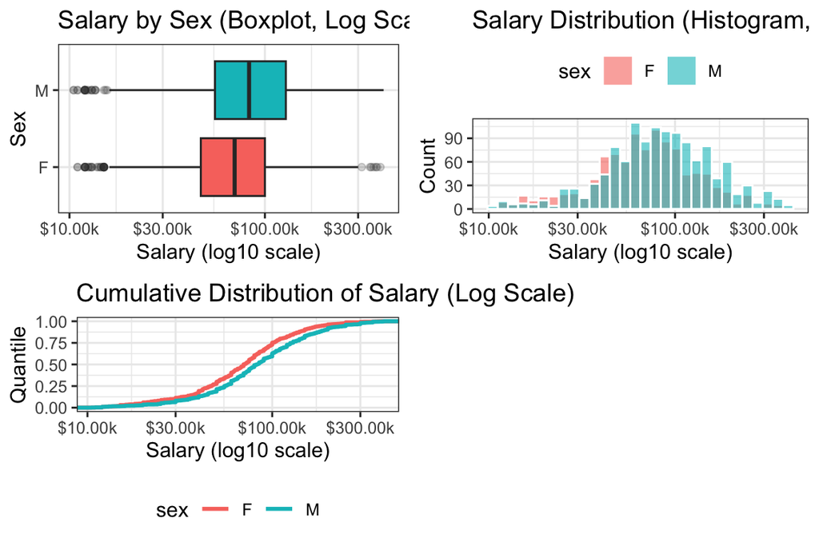

## Question 2

Modify the code that created the `sal_simulate` data frame to create a variable that simulates quantiles from a *cumulative distribution*. Plot these data (instead of a histogram). Hint: instead of `rlnorm()` you will need to use a different log density function that takes a vector of quantiles as input (you will need to specify the quantile vector). Type ?Lognormal into the Console for help.

## Question 3

Mutate the `salary_ps2` data frame to create a new column variable that takes the log of the salary data (call that variable `log.salary`). Then use `fitdistr()` to fit a *normal distribution* to `log.salary`. What are the resultant parameter estimates for the mean and sd? Hint: the output of `fitdistr()` is a list; look in the `estimate` entry for these parameters. How close are these estimates to those calculated in [section 9.6.4](https://smogdr.github.io/edar_coursebook/transform.html#fit-a-log-normal-distribution) of the Coursebook?

```
##     mean       sd
## 4.322399 0.669309
```

# Appendix

```r
# set global options for figures, code, warnings, and messages
knitr::opts_chunk$set(fig.width=6, fig.height=4, fig.path="../figs/",
                      echo=FALSE, warning=FALSE, message=FALSE)
# load packages for current session
library(tidyverse)
library(gridExtra) # or library(patchwork) for arranging figures
library(MASS) # for fitting distributions to your data

salary_ch9 <- readr::read_csv("salary_ch9.csv")

salary_ps2 <- salary_ch9 %>%
  dplyr::mutate(salary = salary/1000) %>% #convert to thousands of $
  dplyr::filter(salary < 500, #censor high outliers
                salary > 10)  #censor low outliers

box2 <- ggplot(salary_ps2, aes(y = sex, x = salary, fill = sex)) +
  geom_boxplot(outlier.alpha = 0.2) +
  scale_x_log10(labels = scales::label_dollar(suffix = "k")) +
  theme_bw() +
  labs(title = "Salary by Sex (Boxplot, Log Scale)",
       x = "Salary (log10 scale)", y = "Sex") +
  theme(legend.position = "none")


hist2 <- ggplot(salary_ps2, aes(x = salary, fill = sex)) +
  geom_histogram(color = "white", bins = 30, position = "identity", alpha = 0.6) +
  scale_x_log10(labels = scales::label_dollar(suffix = "k")) +
  theme_bw() +
  labs(title = "Salary Distribution (Histogram, Log Scale)",
       x = "Salary (log10 scale)", y = "Count") +
  theme(legend.position = "top")


cdf2 <- ggplot(salary_ps2, aes(x = salary, color = sex)) +
  stat_ecdf(size = 1) +
  scale_x_log10(labels = scales::label_dollar(suffix = "k")) +
  theme_bw() +
  labs(title = "Cumulative Distribution of Salary (Log Scale)",
       x = "Salary (log10 scale)", y = "Quantile") +
  theme(legend.position = "bottom")


grid.arrange(box2, hist2, cdf2, nrow = 2, ncol = 2)

fit.lnorm <- fitdistr(salary_ps2$salary, densfun = "log-normal")


sal_quant <- tibble(
  p = seq(0.001, 0.999, length.out = length(salary_ps2$salary)),  # probabilities (avoid 0 and 1)
  q = qlnorm(
    p,
    meanlog = fit.lnorm$estimate[[1]],
    sdlog   = fit.lnorm$estimate[[2]]
  )
)


ggplot() +
  stat_ecdf(data = salary_ps2, aes(x = salary, color = "Observed"), size = 1) +
  geom_line(data = sal_quant, aes(x = q, y = p, color = "Lognormal (theoretical)"), size = 1) +
  labs(title = "Observed vs. Lognormal Cumulative Distribution of Salary",
       x = "Salary", y = "Cumulative Probability") +
  scale_x_continuous(
    labels = function(x) paste0("$", prettyNum(x/1000, big.mark=","), "k")
    # , limits = c(0, 500000)  # uncomment only if you truly need limits in dollars
  ) +
  scale_color_manual(NULL, values = c("Observed" = "navy", "Lognormal (theoretical)" = "darkorange1")) +
  theme_bw() +
  theme(legend.position = "bottom")


salary_ps2 <- salary_ps2 %>%
  mutate(log.salary = log(salary))


fit.norm <- fitdistr(salary_ps2$log.salary, "normal")


fit.norm$estimate
```

[output not shown]

[output not shown]